# Final_Tutorial

**Baseball's crackdown on grip enchancing substances, an Analysis.**

Using Data Science and its processes to determine the effectiveness and rationale of the 2021 mid-season increase of enforcement against the use of gripping substances by pitchers.

Joseph Pupa, May 16, 2022.

Introduction: Two things have long been truths in Major League Baseball: First, its a numbers game, average, on-base-percentage, spin-rate, launch-angle, wins-above-replacement. Over the years, the game has evolved to track the performance of players is every way imaginable, with todays revolution being in the use of radar and other technology systems to track everything down to the acceleration of the bat head on a swing. The other truth is the game's long history of cheating. Virtually everyone is familiar with the Black Sox scanadal of nearly a century ago, or the steroid-era led by the likes of Barry Bonds, Mark McGuire, Samy Sosa, and Alex Rodriguez. In recent years, the Houston Astros have been taken to task for their use of electronics to steal signs en route to a World Series victory. On June 20 of 2021, however, the commisioners office cracked down on a different kind of cheating, the use of pine tar or "sticky stuff" (pine tar and other substances will be refered to as such for the remainder of this document) as it is refered to by pitchers around the sport. Allegedly, pitchers used pine tar to gain extra grip on the ball, thus allowing their spin rate and velocity to increase, making their pitches harder to hit, thus slowing down offenses around the game. In this tutorial, I seek to answer three primary questions. First, as it relates to the pitchers, did this crackdown have an effect on the the features of pitching they felt this exploit gave them a leg up in? Second, did this crack down have an impact on offense around the sport, ie did hitters benefit from what the league saw as leveling the playing field. Third, is there an identifiable linear relationship between the changes they desired to see in both pitching and offense. Answering these questions will allow us to more definitively see whether the use of "sticky stuff" was appropriately combated and to judge the success of their actions against it.

Credit: All pitching data for this project acquired through Baseball Savant, a MLB Advanced Media service specializing in statistical tracking and search. (baseballsavant.mlb.com). All batting data for this project was acquired through FanGraphs, a popular baseball statistics and sabermetrics tracking and reporting outlet. (Fangraphs.com)

To Reproduce this Data:

Baseball Savant:

baseballsavant.mlb.com , Under the "Search" feature, enter the desired statistics and dates in the fields. For example, to reproduce the pitching data before the crackdown, Select Dates of April 1, 2021 through June 20, 2021. Select year 2021. Select Player Type as Pitcher, and then Search. The resulting page gives options to download results as csv.

FanGraphs: fangraphs.com, under Leaders tab. Select batting, pitching, or defense. For example, to reproduce the batting data before the crackdown, Select batting leaders, then select 2021 under "Single Season", and enter the same custom data range as for the pitching data example. The results will appear below. Click "Export Data" to download the data as a csv.

All CSV's used in this project can be found in the public project repository: https://github.com/jpupa8/jpupa8.github.io

Data Collection: For purposes of this project, I will be using pandas, numpy, and matplot lib to help organize and wrangle the data needed to answer the questions posed above. First, it is important to define the data that I will import below. The sticky stuff crackdown occured on June 20, 2021. In order to quantify the impacts of the crackdown, and the use of sticky stuff itself, I have collected two data sets from Baseball Savant (credited above). First, a set called before, which is comprised of all pitching information from opening day of the 2021 season through the date of the crackdown (totaling 80 days of the season). Second, a set called after, is comprised of the following 85 days after the crackdown was announced. I have chosen to extend the second data set by 5 days in order to account for the five day all star break that occurs in mid July, in an effort to roughly balance the amount of baseball played in each data set. Importing this data and printing can be seen in the code below.

```python
import pandas as pd
import numpy as np
import matplotlib.pyplot as plt
import statistics
#Importing pitching data csv's
before = pd.read_csv("before_sticky_ban.csv", sep=',')
after = pd.read_csv("after_crackdown.csv",sep=',')
```

Examining Pitching after the Crackdown:

In order to see what impact, if any, the use of sticky stuff and subsequent crackdown had on pitching. We need to examine what several key stats for pitchers looked like before and after the change. The stats most impacted by sticky stuff according to hitters, pundits, and others around the sport were (Definition provided by MLB StatCast and Baseball Savant) Spin Rate, a measurement of the baseball in revolutions per minute after leaving the pitchers hand, Pitch Velocity, which is self explanatory, and whiffs, which is a measure of swinging strikes recorded by a pitcher. From the hitters perspective, at first look we will look at batting average, a very simple statistic of hits divided by total at bats, as well as launch speed, which represents the average speed the ball comes off the bat, an important denoter to whether hitters are seeing and timing pitchers at a quality mark. In the following code, data from each pitcher is sorted in various lists in order to then create graphs of these stats off of each pitcher using previously credited python libraries (matplotlib). Since we want solid sample sizes for pitch counts, I have chosen to omit any pitcher that did not throw at least 500 pitches. On average in Major League Baseball, an inning is about 15 pitches. This means that our 500 pitch threshold equates to about 33 innings of work needed throughout the first 2.5 months of the season in order to qualify for these plots and statistics. This is an effort to not include pitchers that appeared once for one or two terrible innings or only appeared once and then was sent back down to the minor leagues. By installing a pitch threshold, we will only see mainstay, legitimate Major League Pitchers (those who matter for statistical analaysis like this).

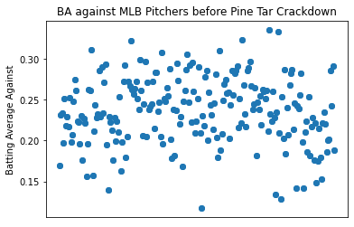

```
Average BA before crackdown off all pitchers who threw over 500 pitches:  0.23639351851851853
```

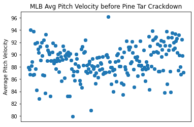

```
Average Pitch Velocity before crackdown off all pitchers who threw over 500 pitches:  88.86527777777778
```

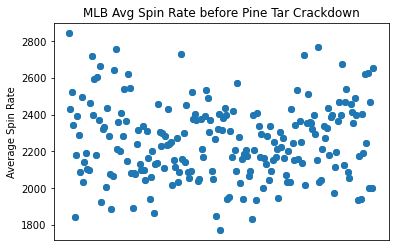

```
Average Spin Rate before crackdown off all pitchers who threw over 500 pitches:  2254
```

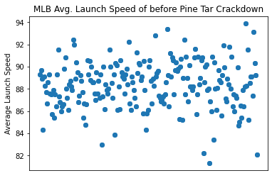

```
Average Launch Speed before crackdown off all pitchers who threw over 500 pitches:  88.33518518518518
```

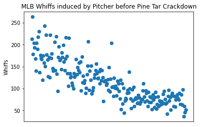

```
Avg. Number of Whiffs induced before crackdown off all pitchers who threw over 500 pitches:  115
```

```python
pitchers = []
avgs = []
velocity = []
spinrate = []
ls = []
whiffs = []
#Currating Stats for each pitcher. Ignoring pitchers who threw less than 500 pitches, as that is a insignificant sample size across 80 days of the season.
for i, row in before.iterrows():
    if(before.at[i, "total_pitches"] > 500):
        pitchers.append(before.at[i, 'player_name'])
        avgs.append(before.at[i, 'ba'])
        velocity.append(before.at[i, 'velocity'])
        spinrate.append(before.at[i, 'spin_rate'])
        ls.append(before.at[i, 'launch_speed'])
        whiffs.append(before.at[i, 'whiffs'])

#Plotting Average
plt.plot(pitchers, avgs, marker = 'o',ls='')
plt.ylabel("Batting Average Against")
plt.title("BA against MLB Pitchers before Pine Tar Crackdown")
plot = plt.scatter(pitchers, avgs)
plot.axes.xaxis.set_ticks([])
plt.show()
avgbefore = statistics.mean(avgs)
print("Average BA before crackdown off all pitchers who threw over 500 pitches: ", avgbefore)

#Plotting Velocity
plt.plot(pitchers, velocity, marker = 'o',ls='')
plt.ylabel("Average Pitch Velocity")
plt.title("MLB Avg Pitch Velocity before Pine Tar Crackdown")
plot = plt.scatter(pitchers, velocity)
plot.axes.xaxis.set_ticks([])
plt.show()
velobefore = statistics.mean(velocity)
print("Average Pitch Velocity before crackdown off all pitchers who threw over 500 pitches: ", velobefore)

#Plotting Spin Rate
plt.plot(pitchers, spinrate, marker = 'o',ls='')
plt.ylabel("Average Spin Rate")
plt.title("MLB Avg Spin Rate before Pine Tar Crackdown")
plot = plt.scatter(pitchers, spinrate)
plot.axes.xaxis.set_ticks([])
plt.show()
srbefore = statistics.mean(spinrate)
print("Average Spin Rate before crackdown off all pitchers who threw over 500 pitches: ", srbefore)

#Plotting Launch Speed
plt.plot(pitchers, ls, marker = 'o',ls='')
plt.ylabel("Average Launch Speed")
plt.title("MLB Avg. Launch Speed of before Pine Tar Crackdown")
plot = plt.scatter(pitchers, ls)
plot.axes.xaxis.set_ticks([])
plt.show()
lsbefore = statistics.mean(ls)
print("Average Launch Speed before crackdown off all pitchers who threw over 500 pitches: ", lsbefore)

#Plotting Whiffs
plt.plot(pitchers, whiffs, marker = 'o',ls='')
plt.ylabel("Whiffs")
plt.title("MLB Whiffs induced by Pitcher before Pine Tar Crackdown")
plot = plt.scatter(pitchers, whiffs)
plot.axes.xaxis.set_ticks([])
plt.show()
wbefore = statistics.mean(whiffs)
print("Avg. Number of Whiffs induced before crackdown off all pitchers who threw over 500 pitches: ",wbefore )
```

From the above code and the produced graphs and statistics, we now have an idea of what these stats looked like across baseball prior to the crackdown. Now, in order for these stats to be contextualized, we must do the same calculations and plotting for the same statistics after the crackdown. Following this, we can determine differences in statistical trends, and make a judgement as to whether the crackdown on sticky stuff had an impact on pitching. Below is code and output for curating the same stats and producing the very same graphs, this time, for the after crackdown data set. Once again, pitchers who threw less than 500 pitches during this time, have been ommited.

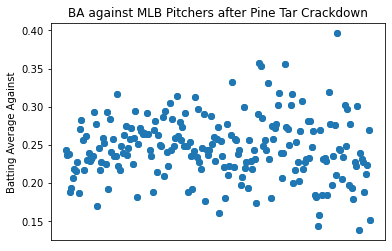

```
Average BA after crackdown off all pitchers who threw over 500 pitches:  0.24567906976744186
```

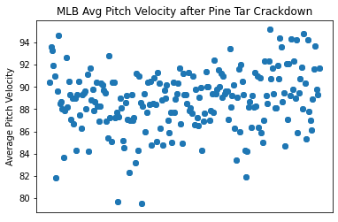

```
Average Pitch Velocity after crackdown off all pitchers who threw over 500 pitches:  88.78744186046512
```

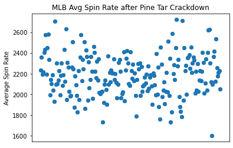

```
Average Spin Rate after crackdown off all pitchers who threw over 500 pitches:  2188
```

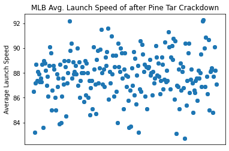

```
Average Launch Speed after crackdown off all pitchers who threw over 500 pitches:  87.78976744186046
```

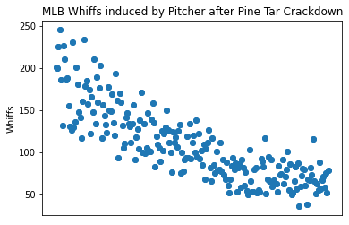

```
Avg. Number of Whiffs induced after crackdown off all pitchers who threw over 500 pitches:  108
```

```python
pitchers = []
avgs = []
velocity = []
spinrate = []
ls = []
whiffs = []
#Currating Stats for each pitcher. Ignoring pitchers who threw less than 200 pitches, as that is a insignificant sample size across 80 days of the season.
for i, row in after.iterrows():
    if(after.at[i, "total_pitches"] > 500):
        pitchers.append(after.at[i, 'player_name'])
        avgs.append(after.at[i, 'ba'])
        velocity.append(after.at[i, 'velocity'])
        spinrate.append(after.at[i, 'spin_rate'])
        ls.append(after.at[i, 'launch_speed'])
        whiffs.append(after.at[i, 'whiffs'])

#Plotting Average
plt.plot(pitchers, avgs, marker = 'o',ls='')
plt.ylabel("Batting Average Against")
plt.title("BA against MLB Pitchers after Pine Tar Crackdown")
plot = plt.scatter(pitchers, avgs)
plot.axes.xaxis.set_ticks([])
plt.show()
avgafter = statistics.mean(avgs)
print("Average BA after crackdown off all pitchers who threw over 500 pitches: ", avgafter)

#Plotting Velocity
plt.plot(pitchers, velocity, marker = 'o',ls='')
plt.ylabel("Average Pitch Velocity")
plt.title("MLB Avg Pitch Velocity after Pine Tar Crackdown")
plot = plt.scatter(pitchers, velocity)
plot.axes.xaxis.set_ticks([])
plt.show()
veloafter = statistics.mean(velocity)
print("Average Pitch Velocity after crackdown off all pitchers who threw over 500 pitches: ", veloafter)

#Plotting Spin Rate
plt.plot(pitchers, spinrate, marker = 'o',ls='')
plt.ylabel("Average Spin Rate")
plt.title("MLB Avg Spin Rate after Pine Tar Crackdown")
plot = plt.scatter(pitchers, spinrate)
plot.axes.xaxis.set_ticks([])
plt.show()
srafter =  statistics.mean(spinrate)
print("Average Spin Rate after crackdown off all pitchers who threw over 500 pitches: ", srafter)

#Plotting Launch Speed
plt.plot(pitchers, ls, marker = 'o',ls='')
plt.ylabel("Average Launch Speed")
plt.title("MLB Avg. Launch Speed of after Pine Tar Crackdown")
plot = plt.scatter(pitchers, ls)
plot.axes.xaxis.set_ticks([])
plt.show()
lsafter = statistics.mean(ls)
print("Average Launch Speed after crackdown off all pitchers who threw over 500 pitches: ", lsafter)

#Plotting Whiffs
plt.plot(pitchers, whiffs, marker = 'o',ls='')
plt.ylabel("Whiffs")
plt.title("MLB Whiffs induced by Pitcher after Pine Tar Crackdown")
plot = plt.scatter(pitchers, whiffs)
plot.axes.xaxis.set_ticks([])
plt.show()
wafter = statistics.mean(whiffs)
print("Avg. Number of Whiffs induced after crackdown off all pitchers who threw over 500 pitches: ", wafter)
```

Analysis of Pitching statistics before and after Crackdown:

Of the five key statistics, four show the desired impact Major League Baseball had when it instituted the increased enforcement on grip enchacing substances. After the crackdown, the batting average against all pitchers (on average) rose by nearly 10 points. Average pitch velocity saw a decline by .1 MPH. Spin Rate saw a decline of 66 RPM. Finally, average Whiffs induced saw a decline of 7. Interestingly, Launch Speed decreased after the crackdown by about .6 MPH, I would tend to attribute this mostly to the average pitch coming in slower, thus, when hit, will also leave the bat somewhat slower. Beside Launch Speed, the crackdown on pine tar and other substances seems to have worked from the pitching point of view. However, did this have an impact on more specfic offensive production categories? After all, these changes were implemented as a result of what the league saw as pitching over powering hitting. We have already seen an uptick in batting average after the crackdown, but what about other key offensive stats. The code below will show the difference before and after the crackdown in several other offensive stats such at Walk Rate (BB%), Strike Out Rate (K%), and On Base Percentage by first importing batting stats acquired through FanGraphs, before applying a very similar process as we completed above to chart the differences.

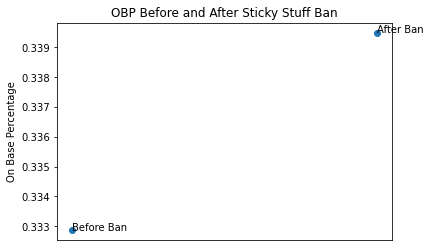

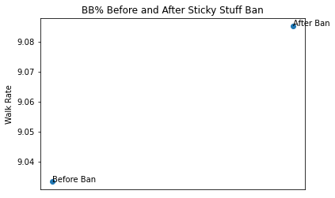

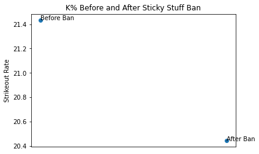

```python
bbat = pd.read_csv("batting_before.csv", sep=',')
abat = pd.read_csv("batting_after.csv",sep=',')
obp = []
bbrate = []
krate = []

#Curating Hitting Stats before crackdown
for i, row in bbat.iterrows():
    obp.append(bbat.at[i, "OBP"])
    #CSV had walk and strikout rates at percentage strings, need to convert
    bbrate.append(float(bbat.at[i, "BB%"].strip('%')))
    krate.append(float(bbat.at[i, "K%"].strip('%')))
#calculating means
obp_before = statistics.mean(obp)
bbrate_before = statistics.mean(bbrate)
krate_before = statistics.mean(krate)
obp.clear()
bbrate.clear()
krate.clear()
#Curating Hitting stats after crackdown
for i, row in abat.iterrows():
    obp.append(abat.at[i, "OBP"])
    bbrate.append(float(abat.at[i, "BB%"].strip('%')))
    krate.append(float(abat.at[i, "K%"].strip('%')))
#calculating means
obp_after = statistics.mean(obp)
bbrate_after = statistics.mean(bbrate)
krate_after = statistics.mean(krate)
x = [1,2]
y = [obp_before, obp_after]
#Creating Scatter Plot, labeling points to represent before and after the rule enforcement changes.
plot = plt.scatter(x, y)
plot.axes.xaxis.set_ticks([])
plt.ylabel("On Base Percentage")
plt.title("OBP Before and After Sticky Stuff Ban")
labels = ["Before Ban", "After Ban"]
for i, label in enumerate(labels):
        plt.annotate(label, (x[i],y[i]))
plt.show()

#Plotting walk rate, same process
y = [bbrate_before, bbrate_after]
plot = plt.scatter(x, y)
plot.axes.xaxis.set_ticks([])
plt.ylabel("Walk Rate")
plt.title("BB% Before and After Sticky Stuff Ban")
labels = ["Before Ban", "After Ban"]
for i, label in enumerate(labels):
        plt.annotate(label, (x[i],y[i]))
plt.show()

#Plotting K rate, same process
y = [krate_before, krate_after]
plot = plt.scatter(x, y)
plot.axes.xaxis.set_ticks([])
plt.ylabel("Strikeout Rate")
plt.title("K% Before and After Sticky Stuff Ban")
labels = ["Before Ban", "After Ban"]
for i, label in enumerate(labels):
        plt.annotate(label, (x[i],y[i]))
plt.show()
```

We have definitively shown that the crackdown on pine tar resulted in two things:

```
1) Statistics usually associated with talented pitching (High Spin Rate, High Whiffs, High Velocity, Low AVG Against) all moved against pitchers
2) Statistics usually associated with high quality batting (Low K Rate, High BB Rate, and High On Base Percentage) all moved in favor of batters.
```

At first thought, it would seem that the crackdown had its desired impact. However, it is vital to identify whether there exists a relationship between the increases and decreases in respective hitting and pitching statistics. In other words, can we show definitively that the changes seen after the crackdown are the result of the rule changes (ie not a coincidence)? Using Linear Regression and Fitting, we will determine how much of a relationship exists between these stats, in order to conclude whether the change in pitching stats (as a result of the rule enforcement) is the reason for the uptick in offensive production. As a specific example, We have seen that on base percentage rose after the ban, but is there a true linear relationship between a decline in various pitching statistics and a rise in on base percentage. Below is code that will carry out these hypothesis' tests and make these determinations. Specifically, this code will compile monthly averages of the pitching and batting stats we have been discussing. Then, using the statsmodels library, we will conduct several OLS/Least Squares analysis tests to identify what correlations/linear relationships exist, this first requires a bit of data wrangling/organizing, as NaN values will need to be removed to ensure proper calculations, and then the actual tests will be created and ran.

```python
import statsmodels.api as sm
from statsmodels.formula.api import ols
import numpy as np

#importing csv files with month by month pitching and hitting statistics
apr_batting = pd.read_csv("apr_batting.csv", sep=',')
may_batting = pd.read_csv("may_batting.csv", sep=',')
jun_batting = pd.read_csv("june_batting.csv", sep=',')
jul_batting = pd.read_csv("july_batting.csv", sep=',')
aug_batting = pd.read_csv("aug_batting.csv", sep=',')
sep_batting = pd.read_csv("sep_batting.csv", sep=',')
apr_pitching = pd.read_csv("april_pitching.csv", sep=',')
may_pitching = pd.read_csv("may_pitching.csv", sep=',')
jun_pitching = pd.read_csv("june_pitching.csv", sep=',')
jul_pitching = pd.read_csv("july_pitching.csv", sep=',')
aug_pitching = pd.read_csv("aug_pitching.csv", sep=',')
sep_pitching = pd.read_csv("sep_pitching.csv", sep=',')

april_stats = []
may_stats = []
june_stats = []
july_stats = []
aug_stats = []
sep_stats = []

months = [apr_pitching, may_pitching, jun_pitching, jul_pitching, aug_pitching, sep_pitching]
#print(apr_batting)
#print(apr_pitching)
spinrate_by_month = []
velo_by_month = []

# Curating monthly spinrate/velo averages across baseball. NaN values removed
for month in months:
    srs = []
    velos = []
    for i, row in month.iterrows():
        srs.append(month.at[i, 'spin_rate'])
        velos.append(month.at[i, 'velocity'])
    #Removing NaN values
    srs = [x for x in srs if np.isnan(x) == False]
    velos = [x for x in velos if np.isnan(x) == False]
    spinrate_by_month.append(statistics.mean(srs))
    velo_by_month.append(statistics.mean(velos))

obp_by_month = []
k_by_month = []
bb_by_month = []
months = [apr_batting, may_batting, jun_batting, jul_batting, aug_batting, sep_batting]

# Curating monthly obp/k/bb averages across baseball.
for month in months:
    obp_by_month.append(month.at[0, 'OBP'])
    k_by_month.append(float(month.at[0, 'K%'].strip('%')))
    bb_by_month.append(float(month.at[0, 'BB%'].strip('%')))

#Ignoring warnings appearing from test. NA to our usage.
import warnings
from statsmodels.tools.sm_exceptions import ValueWarning
warnings.simplefilter('ignore', ValueWarning)

#Test One (Spinrate vs K Rate)
x = spinrate_by_month
y = k_by_month
x = sm.add_constant(x)
test = sm.OLS(y,x).fit()
print(test.summary())
```

```
                            OLS Regression Results
==============================================================================
Dep. Variable:                      y   R-squared:                       0.727
Model:                            OLS   Adj. R-squared:                  0.659
Method:                 Least Squares   F-statistic:                     10.66
Date:                Mon, 16 May 2022   Prob (F-statistic):             0.0309
Time:                        15:11:26   Log-Likelihood:                -2.9997
No. Observations:                   6   AIC:                             9.999
Df Residuals:                       4   BIC:                             9.583
Df Model:                           1
Covariance Type:            nonrobust
==============================================================================
                 coef    std err          t      P>|t|      [0.025      0.975]
------------------------------------------------------------------------------
const        -24.2346     14.528     -1.668      0.171     -64.571      16.102
x1             0.0213      0.007      3.265      0.031       0.003       0.039
==============================================================================
Omnibus:                          nan   Durbin-Watson:                   1.476
Prob(Omnibus):                    nan   Jarque-Bera (JB):                0.861
Skew:                          -0.914   Prob(JB):                        0.650
Kurtosis:                       2.687   Cond. No.                     1.62e+05
==============================================================================

Notes:
[1] Standard Errors assume that the covariance matrix of the errors is correctly specified.
[2] The condition number is large, 1.62e+05. This might indicate that there are
strong multicollinearity or other numerical problems.
```

For each of these tests, we will primarily be focused on the resulting R^2 value. R^2 is represented as a value between 0 and 1 and provides a numerical indicator as to how much of a linear relationship/correlation exists between two (or more) variables. Intuitively, an R^2 of 1 indicates a perfect correlation, and 0 represents no relationship. As we stated earlier, Identifying relationships between the various statistics we have been anaylzing is the final key needed to conclusively determine the success of the crackdown and whether its rationale was correct.

The first test sought to see the relationship between the changes in spin rate throughout the season and the changes in strike out rate. As we can see above, the R^2 in this case is .727, indicated a fairly strong relationship between spin rate and strike out rates.

```python
#Test two: Spinrate vs Walk Rate
x = spinrate_by_month
y = bb_by_month
x = sm.add_constant(x)
test2 = sm.OLS(y,x).fit()
print(test2.summary())
```

```
                            OLS Regression Results
==============================================================================
Dep. Variable:                      y   R-squared:                       0.508
Model:                            OLS   Adj. R-squared:                  0.385
Method:                 Least Squares   F-statistic:                     4.124
Date:                Mon, 16 May 2022   Prob (F-statistic):              0.112
Time:                        15:11:28   Log-Likelihood:                 1.7864
No. Observations:                   6   AIC:                            0.4271
Df Residuals:                       4   BIC:                           0.01067
Df Model:                           1
Covariance Type:            nonrobust
==============================================================================
                 coef    std err          t      P>|t|      [0.025      0.975]
------------------------------------------------------------------------------
const         -4.6191      6.543     -0.706      0.519     -22.785      13.547
x1             0.0060      0.003      2.031      0.112      -0.002       0.014
==============================================================================
Omnibus:                          nan   Durbin-Watson:                   1.582
Prob(Omnibus):                    nan   Jarque-Bera (JB):                0.462
Skew:                          -0.110   Prob(JB):                        0.794
Kurtosis:                       1.658   Cond. No.                     1.62e+05
==============================================================================

Notes:
[1] Standard Errors assume that the covariance matrix of the errors is correctly specified.
[2] The condition number is large, 1.62e+05. This might indicate that there are
strong multicollinearity or other numerical problems.
```

The second test, between spin rate and walk rate, shows a somewhat weak, yet present relationship, with an R^2 of just over .5.

```python
#Test three, Spinrate vs OBP.
x = spinrate_by_month
y = obp_by_month
x = sm.add_constant(x)
test3 = sm.OLS(y,x).fit()
print(test3.summary())
```

```
                            OLS Regression Results
==============================================================================
Dep. Variable:                      y   R-squared:                       0.451
Model:                            OLS   Adj. R-squared:                  0.314
Method:                 Least Squares   F-statistic:                     3.290
Date:                Mon, 16 May 2022   Prob (F-statistic):              0.144
Time:                        15:11:31   Log-Likelihood:                 26.007
No. Observations:                   6   AIC:                            -48.01
Df Residuals:                       4   BIC:                            -48.43
Df Model:                           1
Covariance Type:            nonrobust
==============================================================================
                 coef    std err          t      P>|t|      [0.025      0.975]
------------------------------------------------------------------------------
const          0.5265      0.116      4.558      0.010       0.206       0.847
x1         -9.403e-05   5.18e-05     -1.814      0.144      -0.000    4.99e-05
==============================================================================
Omnibus:                          nan   Durbin-Watson:                   2.208
Prob(Omnibus):                    nan   Jarque-Bera (JB):                0.844
Skew:                          -0.562   Prob(JB):                        0.656
Kurtosis:                       1.547   Cond. No.                     1.62e+05
==============================================================================

Notes:
[1] Standard Errors assume that the covariance matrix of the errors is correctly specified.
[2] The condition number is large, 1.62e+05. This might indicate that there are
strong multicollinearity or other numerical problems.
```

The third test, between spin rate and on base percentage, indicates a weak relationship, with an R^2 of .451.

```python
#Test four, Velocity vs OBP
x = velo_by_month
y = obp_by_month
x = sm.add_constant(x)
test4 = sm.OLS(y,x).fit()
print(test4.summary())
```

```
                            OLS Regression Results
==============================================================================
Dep. Variable:                      y   R-squared:                       0.738
Model:                            OLS   Adj. R-squared:                  0.672
Method:                 Least Squares   F-statistic:                     11.25
Date:                Mon, 16 May 2022   Prob (F-statistic):             0.0285
Time:                        15:11:33   Log-Likelihood:                 28.222
No. Observations:                   6   AIC:                            -52.44
Df Residuals:                       4   BIC:                            -52.86
Df Model:                           1
Covariance Type:            nonrobust
==============================================================================
                 coef    std err          t      P>|t|      [0.025      0.975]
------------------------------------------------------------------------------
const         -0.9707      0.384     -2.528      0.065      -2.037       0.095
x1             0.0145      0.004      3.354      0.028       0.003       0.027
==============================================================================
Omnibus:                          nan   Durbin-Watson:                   1.197
Prob(Omnibus):                    nan   Jarque-Bera (JB):                0.606
Skew:                          -0.121   Prob(JB):                        0.738
Kurtosis:                       1.461   Cond. No.                     3.10e+04
==============================================================================

Notes:
[1] Standard Errors assume that the covariance matrix of the errors is correctly specified.
[2] The condition number is large, 3.1e+04. This might indicate that there are
strong multicollinearity or other numerical problems.
```

The fourth test, between pitch velocity and on base percentage, shows the strongest relationship of any test we conducted, with an R^2 of .738.

```python
#Test Five, velocity vs k rate
x = velo_by_month
y = k_by_month
x = sm.add_constant(x)
test5 = sm.OLS(y,x).fit()
print(test5.summary())
```

```
                            OLS Regression Results
==============================================================================
Dep. Variable:                      y   R-squared:                       0.396
Model:                            OLS   Adj. R-squared:                  0.245
Method:                 Least Squares   F-statistic:                     2.626
Date:                Mon, 16 May 2022   Prob (F-statistic):              0.180
Time:                        15:11:37   Log-Likelihood:                -5.3825
No. Observations:                   6   AIC:                             14.76
Df Residuals:                       4   BIC:                             14.35
Df Model:                           1
Covariance Type:            nonrobust
==============================================================================
                 coef    std err          t      P>|t|      [0.025      0.975]
------------------------------------------------------------------------------
const        191.5561    103.891      1.844      0.139     -96.891     480.004
x1            -1.9011      1.173     -1.621      0.180      -5.158       1.356
==============================================================================
Omnibus:                          nan   Durbin-Watson:                   1.013
Prob(Omnibus):                    nan   Jarque-Bera (JB):                0.550
Skew:                          -0.682   Prob(JB):                        0.760
Kurtosis:                       2.418   Cond. No.                     3.10e+04
==============================================================================

Notes:
[1] Standard Errors assume that the covariance matrix of the errors is correctly specified.
[2] The condition number is large, 3.1e+04. This might indicate that there are
strong multicollinearity or other numerical problems.
```

```python
#Test Six, Velocity vs BB Rate.
x = velo_by_month
y = bb_by_month
x = sm.add_constant(x)
test6 = sm.OLS(y,x).fit()
print(test6.summary())
```

```
                            OLS Regression Results
==============================================================================
Dep. Variable:                      y   R-squared:                       0.001
Model:                            OLS   Adj. R-squared:                 -0.249
Method:                 Least Squares   F-statistic:                  0.002069
Date:                Mon, 16 May 2022   Prob (F-statistic):              0.966
Time:                        15:11:39   Log-Likelihood:               -0.33751
No. Observations:                   6   AIC:                             4.675
Df Residuals:                       4   BIC:                             4.259
Df Model:                           1
Covariance Type:            nonrobust
==============================================================================
                 coef    std err          t      P>|t|      [0.025      0.975]
------------------------------------------------------------------------------
const          6.6284     44.814      0.148      0.890    -117.794     131.051
x1             0.0230      0.506      0.045      0.966      -1.382       1.428
==============================================================================
Omnibus:                          nan   Durbin-Watson:                   1.046
Prob(Omnibus):                    nan   Jarque-Bera (JB):                0.485
Skew:                          -0.602   Prob(JB):                        0.785
Kurtosis:                       2.299   Cond. No.                     3.10e+04
==============================================================================

Notes:
[1] Standard Errors assume that the covariance matrix of the errors is correctly specified.
[2] The condition number is large, 3.1e+04. This might indicate that there are
strong multicollinearity or other numerical problems.
```

The fifth and sixth tests sought to identify relationships between velocity and strikeout and walk rates, respectively. Given R^2 values of .396 and .001, respectively, we would consider neither of these to be strong or significant relationships.

```python
#Test Seven, K Rate vs OBP
x = k_by_month
y = obp_by_month
x = sm.add_constant(x)
test7 = sm.OLS(y,x).fit()
print(test7.summary())
```

```
                            OLS Regression Results
==============================================================================
Dep. Variable:                      y   R-squared:                       0.682
Model:                            OLS   Adj. R-squared:                  0.602
Method:                 Least Squares   F-statistic:                     8.565
Date:                Mon, 16 May 2022   Prob (F-statistic):             0.0430
Time:                        15:11:42   Log-Likelihood:                 27.641
No. Observations:                   6   AIC:                            -51.28
Df Residuals:                       4   BIC:                            -51.70
Df Model:                           1
Covariance Type:            nonrobust
==============================================================================
                 coef    std err          t      P>|t|      [0.025      0.975]
------------------------------------------------------------------------------
const          0.4244      0.037     11.560      0.000       0.322       0.526
x1            -0.0046      0.002     -2.927      0.043      -0.009      -0.000
==============================================================================
Omnibus:                          nan   Durbin-Watson:                   1.814
Prob(Omnibus):                    nan   Jarque-Bera (JB):                0.598
Skew:                          -0.376   Prob(JB):                        0.741
Kurtosis:                       1.648   Cond. No.                         707.
==============================================================================

Notes:
[1] Standard Errors assume that the covariance matrix of the errors is correctly specified.
```

The seventh test sought to identify a relationship between strikeout rates and on base percentage, as we already saw that spin rates and strike out rates are strongly related. With an R^2 of .682, strikeout rates and on base percentage are also seen to have a decently strong linear relationship.

Conclusions:

In the introduction of this project, we sought to identify several things related to Major League Baseball's crackdown on the use of pinetar and other like substances in June of the 2021 baseball regular season.

First, we sought to confirm that several key pitching statistics had seen a decrease after the crackdown as compared to before, and, according to the charts and printed averages during the "before" and "after" periods, we confirmed just that.

Second, we sought to confirm a similar trend with respect to hitters, specifically, whether there was an increase in key offensive statistics after the crackdown as opposed to before, and, once again, according to the charts and printed averages, this was indentified as occuring.

I hope this short tutorial has offered a quality glimpse into the data science process, and, specfically, how raw data can be wrangled, sorted, graphed, analyzed, and tested in order to determine how the mere existence of and (in our case) slight tweaks of interconnected data sets can result in tangible changes in the real world around us.

If baseball statistics and sabermetrics are of an interest to you, I'd highly recommend checking out the two sources for the data used in this project, Baseball Savant and FanGraphs, as both are well organized, up-to-date sources on all things baseball, statistics, and sabermetrics. If you are interested in reading more about this topic, I recommend looking into Bill James, viewed as the inventor of Sabermetrics, who has published several books related to the takeover of data and statistics in the sport.